# Final Paper

STOR 320.01 Group 4

May 01, 2024

# INTRODUCTION

In February, the World Health Organization published a [sobering forecast](https://www.who.int/news/item/01-02-2024-global-cancer-burden-growing--amidst-mounting-need-for-services): “Over 35 million new cancer cases are predicted in 2050, a 77% increase from the estimated 20 million in 2022.” The WHO’s estimate comes amidst a flurry of news reports about an [increase in the number of young people diagnosed with cancer](https://health.ucdavis.edu/blog/cultivating-health/cancer-is-on-the-rise-in-younger-adults-what-to-know-about-screening-and-your-risk/2024/04). In March, The New York Times reported that “millennials born around 1990 now have twice the risk of colon cancer compared with people born around the 1950s, while millennials’ risk for rectal cancer is about four times higher than that of older age groups, according to a study published in the [Journal of the National Cancer Institute](https://academic.oup.com/jnci/article/109/8/djw322/3053481).”

Researchers have identified associations between certain activities, lifestyles and diets — such as smoking, eating red meat and consuming processed foods — with cancer risk. But these factors alone might not explain the full picture, per [a recent quote](https://www.nature.com/articles/d41586-024-00720-6) by a National University of Singapore hepatologist: “Many have hypothesized that things like obesity and alcohol consumption might explain some of our findings — but it looks like you need a deeper dive into the data.”.

Our paper centers on another conceivable suspect for higher cancer instance rates in younger populations: deteriorating environmental conditions. The [prevalence of microplastics](https://www.ncbi.nlm.nih.gov/pmc/articles/PMC10340669/) in the environment has been studied as a potential “driver” for the early onset of colorectal cancer; so too have different [air pollutants](https://www.aacr.org/patients-caregivers/progress-against-cancer/air-pollution-associated-cancer/) and [water pollutants](https://www.health.state.mn.us/communities/environment/hazardous/topics/cancerenvt.html). The threat of climate change compounds these concerns.

Specifically, our group aims to predict cancer instance rates in each North Carolina county based on that county’s environmental quality indicators. We seek to understand which compounds and environmental variables play the greatest role in determining cancer instance rates in the state, and which environmental subdomains most influence counties’ cancer instance rate projections. The answers to these questions may hold significant practical applications because they can offer stakeholders actionable insights, guide policy decisions, steer resource allocation and shape public health initiatives.

- Question 1: Is there a specific domain within the EQI (Environmental Quality Index) dataset that exhibits a higher propensity for predicting cancer incidence rates?
- Question 2: What are the most reliable indicators for identifying counties with the highest incidence rates of cancer? Conversely, what factors are indicative of counties with the lowest rates of cancer?

# DATA

We analyzed data from the North Carolina Department of Health and Human Services’ [NC State Center for Health Statistics](https://schs.dph.ncdhhs.gov/data/cancer.cfm) to identify patterns in cancer instance rates and predict future instance rates based on the corresponding environmental quality indicators (EQI) for each North Carolina county. EQI data is sourced from the [Environmental Protection Agency](https://www.epa.gov/healthresearch/environmental-quality-index-eqi). All datasets utilized in this project are relevant to the year 2013.

The primary dataset we use in this analysis is titled “County-level cumulative environmental quality associated with cancer incidence.” This dataset, sourced from the EPA, offers a comprehensive array of data points used to assess environmental quality. It holds more than 3000 observations that each detail a county in the United States; we created a subset that focuses on just the 100 counties in North Carolina. Data is collected on five critical areas: We split the original data into subdomain subsets — an `air` subset, a `water` subset, a `land` subset, a `built` subset (for built environment), and a `sociodemo` subset (for sociodemographic factors). Subdomains serve as a way to group individually recorded levels of various chemicals, carcinogens, and pollutants in the environment based on which part of the environment those compounds are found in. It is important to keep in mind that certain compounds can be far more dangerous than others even in smaller quantities. We will address how we accounted for this later in this paper.

| Domain | Variables | Description |
| --- | --- | --- |
| Air | Criteria Air Pollutants | Metrics related to air quality and pollutants |
|  | Hazardous Air Pollutants | Measures of hazardous air pollutants |
| Water | General Water Contamination | Indicators of water quality and contamination |
|  | Chemical Contamination | Metrics assessing chemical contamination of water |
| Land | Agricultural Environment | Factors related to land quality and agriculture |
|  | Pesticides | Presence and impact of pesticides on the land |
| Built-Environment | Traffic-Related Environment | Characteristics of the built environment and traffic |
|  | Public Housing Conditions | Conditions of public housing in different areas |
| Sociodemographic | Socioeconomic Factors | Indicators of socioeconomic status and disparities |
|  | Crime Rates | Rates of crime within communities |

We joined the NCDHHS cancer instance rate dataset to the EQI dataset to create our final data frame for analysis. The NCDHHS dataset comprises 100 observations, matching the number of counties in North Carolina. The cancer instance rate for each county is “the number of cancer cases (or deaths) divided by the number of people in the state and are usually expressed as the number of cases (or deaths) per 100,000 people,” per the NC State Center for Health Statistics website. By honing in on county-level insights, our group believes we can help researchers and policymakers on the state level tailor their approaches based on countywide discrepancies and help local-level governments take relevant action. Also, it is important to note that North Carolina’s public health infrastructure is largely decentralized, and therefore many public health decisions might be left up to local governments.

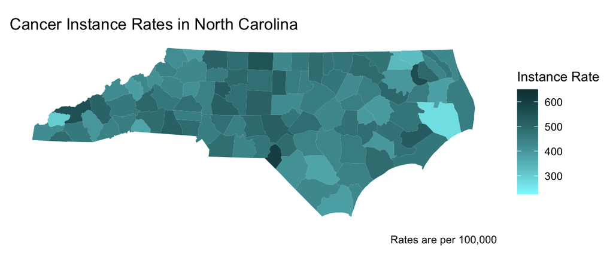

There are not many news articles that refer to cancer instance rates. One piece that discussed the presence of high cancer death rate “hotspots” in the state noted that as of 2016, researchers at UNC-Chapel Hill did not fully understand why such “hotspots” existed, according to [reporting by NC Health News](https://www.northcarolinahealthnews.org/2016/08/09/high-death-rates-in-cancer-hotspots-across-nc/). One of the study’s authors noted, though, that “it wasn’t a simple relationship with race or income level, education level and things like that,” and poor outcomes could perhaps be attributed to local health structures.

# RESULTS

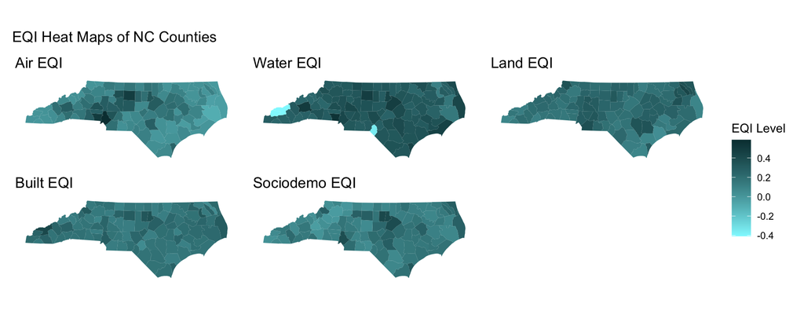

To find which subdomains in the EQI dataset had a higher propensity for predicting cancer instance rates, we created a standardized “score” for each subdomain. The score was calculated by separating the data frame into subsets based on environmental subdomain, scaling these compounds, weighting each compound in each subset equally, and summing the weighted values (*weight* * *scaled value*). We chose to weigh each compound in the subsets equally because we are not healthcare or environmental experts, and therefore cannot assess whether one compound is more potent or dangerous than others. There was also simply too much data to analyze – it wasn’t feasible to research each compound. Also, we standardized the factors in each domain using the `scale()` function, by centering the factors around zero and scaling them to have a standard deviation of one we wereable to deal with the varying levels of measurements, ensuring comparability between variables of different scales and units for robust statistical analysis. Lastly, we standardized the EQI values across all counties in the US to prevent skewing our data. This approach allows us to grasp the EQI levels for NC in comparison to the entire US. If we only normalized NC, we would observe values gravitating towards either extremely safe or hazardous EQI levels.

| County | Air_EQI | Water_EQI | Land_EQI | Built_EQI | Sociodemo_EQI | Instance_Rate |
| --- | --- | --- | --- | --- | --- | --- |
| Alamance | 0.2622304 | 0.3709987 | 0.3148037 | 0.1893730 | 0.1659640 | 522.2 |
| Alexander | 0.0941577 | 0.3372648 | 0.1726654 | 0.0842781 | -0.0020945 | 412.2 |
| Alleghany | 0.0077271 | 0.2945592 | 0.2104160 | 0.1956866 | 0.0821525 | 385.9 |
| Anson | 0.0292089 | 0.2876938 | 0.2505734 | 0.1354885 | 0.0717717 | 435.7 |
| Ashe | 0.0123272 | 0.2958437 | 0.3536635 | 0.1413591 | 0.0330101 | 416.5 |
| Avery | 0.0281592 | 0.3059117 | 0.2537139 | 0.2251982 | 0.1825277 | 410.7 |
| Beaufort | 0.0873377 | 0.2611547 | 0.2622810 | 0.2151538 | 0.1055509 | 466.5 |
| Bertie | 0.0122722 | 0.2964206 | 0.2156300 | 0.1807322 | 0.0802994 | 396.8 |
| Bladen | -0.0024717 | 0.3202200 | 0.1258886 | 0.1819618 | 0.0636197 | 373.3 |
| Brunswick | 0.0615038 | 0.3300145 | 0.0844193 | 0.1951722 | 0.1873441 | 384.9 |

### Q1: Identifying Domains with Predictive Power for Cancer Incidence Rates

In our initial question, we used cross-validation using linear regression models for each subdomain’s EQI score against cancer instance rates for each county. The Root Mean Square Error (RMSE) and Mean Absolute Error (MAE) were chosen as evaluation metrics to assess the predictive performance of environmental domains to estimate cancer instance rates. RMSE quantifies the average magnitude of errors between predicted and actual values while considering the squared differences, making it sensitive to outliers. MAE measures the average magnitude of errors without considering their direction, providing a straightforward interpretation of prediction accuracy. By using both metrics in cross-validation with 25 folds and 10 repeats, the analysis aims to provide a robust evaluation of the models’ accuracy and precision. This approach ensures thorough validation and reduces bias, leading to more reliable insights into the predictive power of environmental domains in assessing cancer risk.

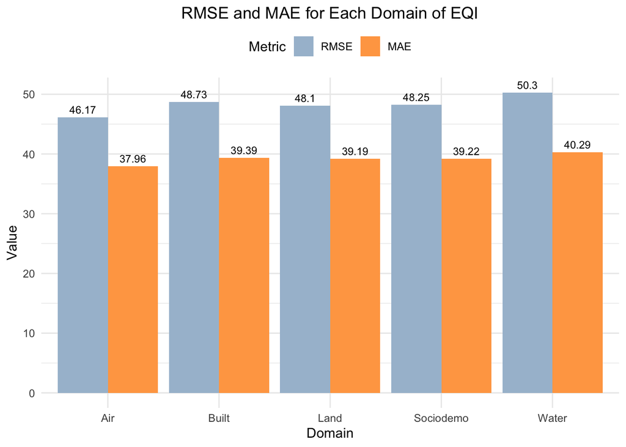

The results of the cross-validation process revealed varying predictive abilities among the different environmental domains. Air quality exhibited the lowest RMSE among the subdomains, suggesting it may have a higher propensity for predicting cancer incidence rates. This finding indicates that air quality metrics such as criteria air pollutants and hazardous air pollutants (HAPs) could serve as valuable indicators for assessing cancer risk at the state level.

The cross-validation results further underscored the importance of considering multiple environmental domains when predicting cancer incidence rates. While air quality emerged as a significant predictor, other domains such as water, land, built environment, and sociodemographic factors also demonstrated predictive power, albeit to varying degrees. This highlights the complex interplay between environmental factors and cancer incidence – something that must be accounted for in similar analyses.

### Q2: Best Predictors for the Counties with the Highest and Lowest Cancer Instance Rates

To answer our second question, we created a combined dataset comprised of all the scaled and merged subsets from Q1, because for this question we are looking at all 215 individual predictors and not grouped subdomains. We split the combined dataset into two groups: the 10 counties with the highest instance rates and the 10 counties with the lowest instance rates. We opted for a top 10 and bottom test based on visual inspection. We reasoned that if the characteristics of the top and bottom groups were too similar, there would likely be significant overlap in predictors, which we aimed to minimize. Thus, we selected the top 10 percentile and bottom 10 percentile for our analysis.

**The Top 10 Counties:**

| Rank | County |
| --- | --- |
| 1 | Scotland |
| 2 | Chowan |
| 3 | Swain |
| 4 | Rockingham |
| 5 | Pamlico |
| 6 | Davie |
| 7 | Alamance |
| 8 | Moore |
| 9 | Rowan |
| 10 | Cleveland |

**The Bottom 10 Counties:**

| Rank | County |
| --- | --- |
| 1 | Hyde |
| 2 | Graham |
| 3 | Gates |
| 4 | Hertford |
| 5 | Polk |
| 6 | Bladen |
| 7 | Tyrrell |
| 8 | Brunswick |
| 9 | Alleghany |
| 10 | Yancey |

Next, we used cross-validation, using MAE as our evaluation metric, to discern the top 15 environmental predictors. We chose to use MAE over RMSE because MAE is robust to outliers – real-world datasets no doubt contain standouts. Thus, MAE provides a more resilient measure of model performance by capturing the absolute differences between predicted and observed values without squaring them. By prioritizing MAE, we aim to yield more reliable and interpretable results, enhancing the validity and suitability of our findings.

We used a 10-fold cross-validation strategy to balance comprehensive model assessment and computational efficiency. 10-fold cross-validation enables robust estimation of model performance while maximizing the utilization of available data. By dividing the dataset into ten equally sized subsets and interactively training the model on nine subsets while validating on the remaining subset, 10-fold cross-validation enables robust estimation of model performance while maximizing the utilization of available data. Additionally, incorporating three repeats of the cross-validation process enhances the robustness of the findings by mitigating the potential variability introduced by random partitioning of the data. This iterative approach to cross-validation ensures that the identified predictors demonstrate consistent performance across multiple iterations, enhancing the reliability and applicability of the results.

#### **Best Predictors for the Top 10 Counties based on Instance Rate**

| Predictors | MAE | Definition |
| --- | --- | --- |
| pct_pers_lt_pov | 15.68463 | Percent persons less than poverty level |
| HCBD | 17.04361 | Hexachlorobutadiene in the air |
| med_hh_inc | 17.14991 | Median household income |
| SEWAGENPDESperKM | 18.04071 | Sewage Permits per 1000 km of Stream in County |
| Air_11DCE | 18.68784 | Vinylidene chloride in the air |
| EtCl | 18.81764 | Ethyl chloride in the air |
| Air_CN | 18.93422 | Cyanide compounds in the air |
| ALPHA | 19.01504 | cis-1,2-Dichloroethylene in the water |
| 2NP | 19.13715 | 2-nitropropane |
| MIBK | 19.24307 | Methyl isobutyl ketone in the air |
| PNP | 19.40670 | 4-nitrophenol in the air |
| TI | 19.51667 | Thallium in the water |
| Toluene | 19.74105 | Toluene in the air |
| P | 19.75484 | Phosphorus in the air |
| CS2 | 19.76953 | Carbon disulfide in the air |

The analysis of the 10 counties with the highest instance rates unveiled several predictors with notably lower MAE values, indicative of their heightened predictive power compared to the 10 counties with the lowest instance rates. Variables such as the percentage of persons living below the poverty line (`pct_pers_lt_pov`), median household income (`med_hh_inc`), and various air quality indicators (e.g., `Air_11DCE`, `Air_CN`) emerged as prominent predictors in this group. These findings underscore the significant association between socioeconomic factors and environmental quality with higher cancer incidence rates in specific counties.

#### **Best Predictors for the Bottom 10 Counties based on Instance Rate**

| Predictors | MAE | Definition |
| --- | --- | --- |
| Air_DEHP | 25.41328 | Bis-2-ethylhexyl phthalate in the air |
| pct_no_eng | 28.66454 | Percent no English |
| Chloroprene | 28.99381 | Chloroprene in the air |
| MeCl | 29.22294 | Methyl chloride in the air |
| Toluene | 29.75902 | Toluene in the air |
| XYLENES | 30.03870 | Xylenes in the water |
| farms_per_acres | 30.63997 | Farms per acre |
| ECH | 30.67312 | Epichlorohydrin in the air |
| Isophorone | 30.89668 | Isophorone in the air |
| PCBs | 30.94171 | Polychlorinated biphenyls in the air |
| DMF | 31.38183 | Dimethyl formamide in the air |
| Air_11DCE | 31.65118 | Vinylidene chloride in the air |
| Air_HCCPD | 31.91944 | Hexachlorocyclopentadiene in the air |
| PAHPOM | 31.92050 | PAH/POM in the air |
| HCBD | 32.00586 | Hexachlorobutadiene in the air |

For the 10 counties with the lowest instance rates, the MAE values for the identified predictors were comparatively higher. However, variables such as air pollutants (e.g., `Air_DEHP`, `Air_HCCPD`), socio-economic indicators (e.g., `pct_no_eng`), and industrial chemicals (e.g., `Chloroprene`, `MeCl`) still exhibited substantial predictive power. Despite the relatively higher MAE values, these predictors provide valuable insights into the factors influencing cancer incidence rates in regions with lower instance rates.

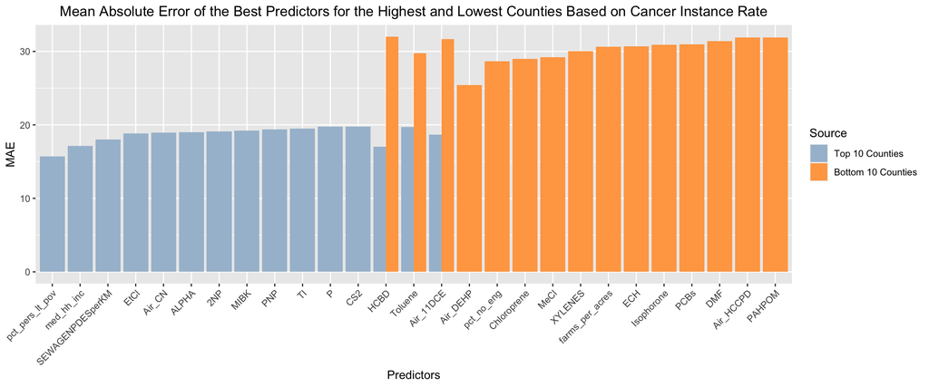

Furthermore, the presence of overlapping predictors between the top and bottom groups highlights the nuanced nature of these relationships, warranting further investigation into the underlying mechanisms driving regional disparities in cancer incidence rates. The presence of the variables `HCBD`, `Toluene`, and `Air_11DCE` in both the top and bottom groups is intriguing. While their inclusion suggests a potential role in predicting cancer instance rates, their consistent presence across groups raises questions about their effectiveness as exclusive predictors.

# CONCLUSION

Future research could utilize additional modeling techniques and employ more comprehensive datasets to enhance the predictive accuracy of cancer incidence rate models. Utilizing advanced machine learning algorithms, such as random forests or gradient boosting, may offer improved performance and better capture the complex interactions between predictor variables. Additionally, it is important to note that our analysis – similar to other comparable analyses – did not account for all the nuances of cancer and cancer diagnoses, like genetic predisposition, diet or healthcare accessibility, and instead focused on one potential catalyst for higher cancer instance rates.

Overall, our analysis offers a way for county governments to address various factors that may influence local cancer instance rates. County governments can use these insights to shape public health initiatives — which is particularly important given North Carolina’s decentralized public health infrastructure. By offering actionable insights, we inform resource allocation, help shape public health initiatives, and put forth a solid first step for addressing the burgeoning impact of cancer in North Carolina and beyond.